# Applied Regression Data Analysis #1

Benjamin Panny

Due January 25th, 2023

# Load Packages and Data

```r
library(tidyverse)
dat <- read_csv('DA1.csv', show_col_types = FALSE)
dat %>% glimpse
```

```
## Rows: 42
## Columns: 4
## $ y  <dbl> 47, 38, 47, 39, 44, 64, 58, 49, 57, 42, 54, 60, 33, 55, 36, 36, 55,…
## $ x1 <dbl> 287, 236, 255, 135, 121, 171, 260, 237, 192, 349, 263, 223, 316, 28…
## $ x2 <dbl> 111, 135, 98, 63, 46, 103, 227, 157, 115, 408, 103, 102, 274, 130, …
## $ x3 <dbl> 0, 0, 0, 0, 0, 0, 0, 0, 1, 1, 1, 1, 0, 0, 0, 0, 0, 0, 0, 1, 1, 1, 1…
```

# Background

A quantitative analysis of factors found in high-density lipoprotein (HDL) in 42 samples of human blood serum found three variables thought to be associated with HDL (y). These variables were total cholesterol level (x1), total triglyceride level (x2) and a component called sinking pre-beta (x3), which was coded as 0 if absent and 1 if present (dummy variable).

# Data Analyses

## Fit simple linear regression models

1. Fit separate simple linear regression models for assessing the association of total cholesterol level (x1), total triglyceride level (x2) and sinking pre-beta (x3) with HDL (y). Using these separate models, test whether x1, x2 or x3 alone statistically significantly predict y. Interpret your answer.

```r
lm_1 <- lm(y ~ x1, data = dat)
lm_2 <- lm(y ~ x2, data = dat)
lm_3 <- lm(y ~ x3, data = dat)
```

```r
lm_1 %>% summary
```

```
##
## Call:
## lm(formula = y ~ x1, data = dat)
##
## Residuals:
##     Min      1Q  Median      3Q     Max
## -18.649  -8.066  -1.267   7.827  28.189
##
## Coefficients:
##             Estimate Std. Error t value Pr(>|t|)
## (Intercept) 52.47018    7.58057   6.922 2.41e-08 ***
## x1          -0.01758    0.02763  -0.636    0.528
## ---
## Signif. codes:  0 '***' 0.001 '**' 0.01 '*' 0.05 '.' 0.1 ' ' 1
##
## Residual standard error: 10.69 on 40 degrees of freedom
## Multiple R-squared:  0.01002,    Adjusted R-squared:  -0.01473
## F-statistic: 0.4049 on 1 and 40 DF,  p-value: 0.5282
```

x1 is not alone a statistically significant predictor of y. lm_1 gives no statistical reason to believe that total cholesterol level is related to expected HDL.

```r
lm_2 %>% summary
```

```
##
## Call:
## lm(formula = y ~ x2, data = dat)
##
## Residuals:
##     Min      1Q  Median      3Q     Max
## -21.114  -7.812  -1.188   8.776  27.407
##
## Coefficients:
##              Estimate Std. Error t value Pr(>|t|)
## (Intercept) 46.245193   3.887115  11.897 1.03e-14 ***
## x2           0.009782   0.022690   0.431    0.669
## ---
## Signif. codes:  0 '***' 0.001 '**' 0.01 '*' 0.05 '.' 0.1 ' ' 1
##
## Residual standard error: 10.71 on 40 degrees of freedom
## Multiple R-squared:  0.004625,   Adjusted R-squared:  -0.02026
## F-statistic: 0.1859 on 1 and 40 DF,  p-value: 0.6687
```

x2 is not alone a statistically significant predictor of y. lm_2 gives no statistical reason to believe that total triglyceride level is related to expected HDL.

```r
lm_3 %>% summary
```

```
##
## Call:
## lm(formula = y ~ x3, data = dat)
##
## Residuals:
##      Min       1Q   Median       3Q      Max
## -16.7727  -7.7727  -0.7727   5.6943  23.8500
##
## Coefficients:
##             Estimate Std. Error t value Pr(>|t|)
## (Intercept)   43.773      2.099  20.851  < 2e-16 ***
## x3             8.377      3.042   2.754  0.00882 **
## ---
## Signif. codes:  0 '***' 0.001 '**' 0.01 '*' 0.05 '.' 0.1 ' ' 1
##
## Residual standard error: 9.847 on 40 degrees of freedom
## Multiple R-squared:  0.1594, Adjusted R-squared:  0.1383
## F-statistic: 7.583 on 1 and 40 DF,  p-value: 0.008822
```

x3 is alone a statistically significant predictor of y. The presence of sinking pre-beta is associated with an estimated 8.377 unit increase in average HDL. About 15.94% of the variance in HDL is accounted for by this model.

## Fit multivariable model

2. Fit a multivariable model and test whether x1, x2 and x3 taken together statistically significantly predict y. Interpret your answer.

```r
full_lm <- lm(y ~ x1 + x2 + x3, data = dat)
full_lm %>% summary()
```

```
##
## Call:
## lm(formula = y ~ x1 + x2 + x3, data = dat)
##
## Residuals:
##     Min      1Q  Median      3Q     Max
## -14.140  -7.065  -1.226   6.284  22.616
##
## Coefficients:
##             Estimate Std. Error t value Pr(>|t|)
## (Intercept) 48.86453    7.24985   6.740 5.54e-08 ***
## x1          -0.02731    0.03015  -0.906   0.3707
## x2           0.01504    0.02485   0.605   0.5486
## x3           8.14831    3.11224   2.618   0.0126 *
## ---
## Signif. codes:  0 '***' 0.001 '**' 0.01 '*' 0.05 '.' 0.1 ' ' 1
##
## Residual standard error: 9.992 on 38 degrees of freedom
## Multiple R-squared:  0.1777, Adjusted R-squared:  0.1128
## F-statistic: 2.737 on 3 and 38 DF,  p-value: 0.05682
```

Considered together, x3 remains the only factor that is statistically significantly related to y through a beta estimate of ~8.15. In the context of this model, compared to the simple model for x3, the presence of sinking pre-beta is associated with an ~8.15 unit increase in HDL. About 17% of the variance in HDL is accounted for by this model. However, the overall F-statistic indicates that x1, x2, and x3 together do not significantly contribute to HDL, but are close to doing so.

## Test x3 is associated with y after x1 and x2 are accounted for

3. Fit a multivariable and test whether x3 is associated with y after the combined contribution of x1 and x2 is taken into account (i.e., x1 and x1 are already in the model). Assume no interactions exist. State the appropriate null hypothesis for this test and interpret the results of the test.

```r
anova(full_lm)
```

```
## Analysis of Variance Table
##
## Response: y
##           Df Sum Sq Mean Sq F value  Pr(>F)
## x1         1   46.2   46.24  0.4631 0.50030
## x2         1   89.1   89.15  0.8929 0.35066
## x3         1  684.4  684.37  6.8547 0.01263 *
## Residuals 38 3793.9   99.84
## ---
## Signif. codes:  0 '***' 0.001 '**' 0.01 '*' 0.05 '.' 0.1 ' ' 1
```

The null hypothesis for this test is that the effect of pre-sinking beta presence on HDL does not exist / equals zero when the model already contains total cholesterol level and total triglyceride level. The ANOVA table indicates that x3 adds significantly to the model already containing x1 and x2.

## Test for contribution of pair-wise interactions after simple effects.

4. Fit a multivariable and test whether the interactions of x1*x3 and x2*x3 are simultaneously equal to zero in a model already containing x1, x2 and x3. Write down the model statement for the model you need to fit to assess this. State the null hypothesis of the test. Given the result of the test, what can you conclude about the relationship of y to both x1 and x2 (hint: remember what an interaction means)?

```r
lm_pair_int <- lm(y ~ x1 + x2 + x3 + x1:x3 + x2:x3, data = dat)
lm_pair_int_2 <-  lm(y ~ x1 + x2 + x3 + x1:x2 + x1:x3, data = dat)
anova(lm_pair_int)
```

```
## Analysis of Variance Table
##
## Response: y
##           Df Sum Sq Mean Sq F value  Pr(>F)
## x1         1   46.2   46.24  0.4476 0.50777
## x2         1   89.1   89.15  0.8629 0.35911
## x3         1  684.4  684.37  6.6246 0.01432 *
## x1:x3      1   48.7   48.69  0.4713 0.49678
## x2:x3      1   26.1   26.13  0.2529 0.61808
## Residuals 36 3719.1  103.31
## ---
## Signif. codes:  0 '***' 0.001 '**' 0.01 '*' 0.05 '.' 0.1 ' ' 1
```

```r
anova(lm_pair_int_2)
```

```
## Analysis of Variance Table
##
## Response: y
##           Df Sum Sq Mean Sq F value  Pr(>F)
## x1         1   46.2   46.24  0.4854 0.49045
## x2         1   89.1   89.15  0.9359 0.33978
## x3         1  684.4  684.37  7.1851 0.01102 *
## x1:x2      1  284.5  284.50  2.9869 0.09251 .
## x1:x3      1   80.5   80.46  0.8448 0.36415
## Residuals 36 3428.9   95.25
## ---
## Signif. codes:  0 '***' 0.001 '**' 0.01 '*' 0.05 '.' 0.1 ' ' 1
```

The null hypothesis is that the effects of the pair-wise interactions between x1:X2 and x1:x3 are zero after taking x1, x2, and x3 into account. Neither interaction model, testing for the contribution of x1:x2 and x1:x3 in each order after taking simple effects into account, indicates through the ANOVA table that these contributions are significant.

## Compare coefficients for x3 in simple model vs. multivariate model

5. For pre-sinking beta (x3), compare the coefficient for x3 in model in part c to the simple model containing only x3 in part a. Do you think there is confounding due to x1 and x2? Explain.

```r
lm_3$coefficients["x3"]
```

```
##       x3
## 8.377273
```

```r
full_lm$coefficients["x3"]
```

```
##       x3
## 8.148309
```

The coefficient appears slightly larger in the simple model. I do not believe there is negative confounding as a result of x1 or x2 because they are not statistically significantly related to HDL, even if I were to assume association with the predictor x3 and that they are not part of a hypothesized causal pathway.

## Model to specify two separate lines

6. Assume straight line models are appropriate for describing the relationship between HDL (y) and total cholesterol level (x1) for the absence of sinking pre-beta(x3=0) and the presence of sinking pre-beta (x3=1). Write out a single regression model that specifies two separate lines, one for the absence of sinking pre-beta (x3=0) and one for the presence of sinking pre-beta (x3=1).

## Fitting model that specifies two separate lines

7. Fit this model in part f. using regress and write out each estimated equation for absence and presence of sinking pre-beta (fit one model but write two separate equations).

$$\begin{align}
y &= \beta_0 + \beta_1 * x1 + \beta_3 * x3 + \beta_{1,3} * x1 * x3
\\
y &= \beta_0 + \beta_1 * x1 &&\text{absence} \\
y &= \beta_0 + \beta_3 + \left( \beta_1 + \beta_{1,3} \right) * x1
&&\text{presence}
\end{align}$$

```r
lm_sep <- lm(y ~ x1*x3, data = dat)
```

## Plotting the two fit lines

8. Plot the observed data and the fitted lines from part f. for each value of sinking pre-beta (either 2 separate graphs with the same y axes or two plots on one graph (i.e. two plots overlayed; see examples from live session).

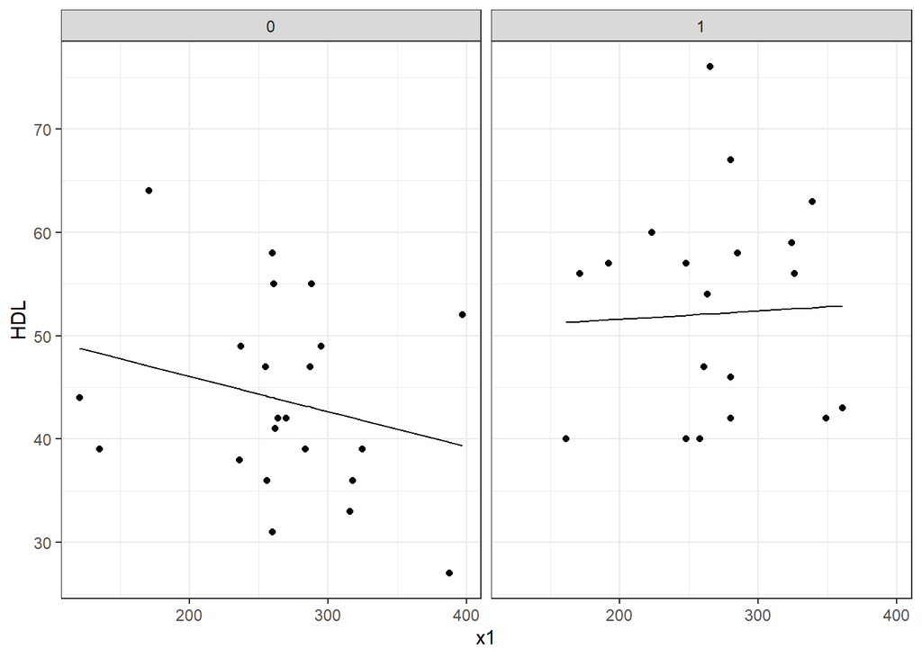

```r
dat_lm_sep <-  dat %>%  mutate(predicted = predict(lm_sep))
dat_lm_sep %>%  ggplot(aes(x=x1, y=y)) +
      geom_point() +
      geom_line(aes(y=predicted)) +
      facet_wrap(~x3) +
      labs(y="HDL") +
      theme_bw()
```

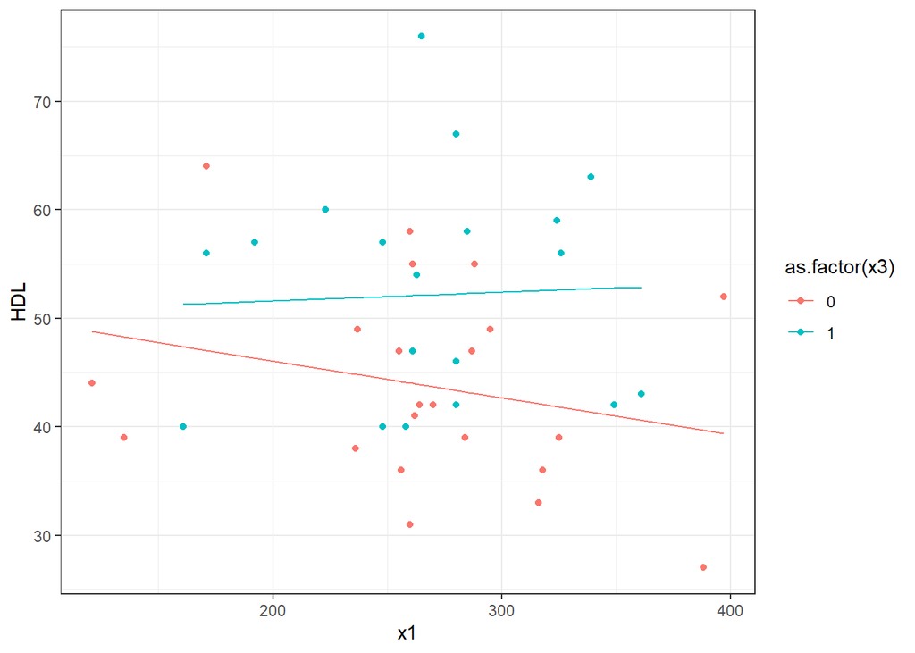

```r
dat_lm_sep %>%  ggplot(aes(x=x1, y=y, group = x3, color = as.factor(x3))) +
      geom_point() +
      geom_line(aes(y=predicted)) +
      labs(y="HDL") +
      theme_bw()
```

## Testing for coincidence (equal lines)

1. Fit the model you need to test for coincidence of the two lines in part f. Perform the test and interpret.

```r
anova(lm_1, lm_sep)
```

```
## Analysis of Variance Table
##
## Model 1: y ~ x1
## Model 2: y ~ x1 * x3
##   Res.Df    RSS Df Sum of Sq      F  Pr(>F)
## 1     40 4567.4
## 2     38 3768.0  2    799.36 4.0307 0.02585 *
## ---
## Signif. codes:  0 '***' 0.001 '**' 0.01 '*' 0.05 '.' 0.1 ' ' 1
```

## Test for parallelism (equal slopes)

10. Fit the model you need to test for parallelism of the two lines in part f. Perform the test and interpret.

```r
lm_sep %>%  summary
```

```
##
## Call:
## lm(formula = y ~ x1 * x3, data = dat)
##
## Residuals:
##     Min      1Q  Median      3Q     Max
## -13.030  -8.883  -1.791   6.051  23.875
##
## Coefficients:
##             Estimate Std. Error t value Pr(>|t|)
## (Intercept) 52.88315    9.03305   5.854 9.02e-07 ***
## x1          -0.03405    0.03282  -1.038    0.306
## x3          -2.86205   14.50782  -0.197    0.845
## x1:x3        0.04199    0.05292   0.793    0.432
## ---
## Signif. codes:  0 '***' 0.001 '**' 0.01 '*' 0.05 '.' 0.1 ' ' 1
##
## Residual standard error: 9.958 on 38 degrees of freedom
## Multiple R-squared:  0.1833, Adjusted R-squared:  0.1188
## F-statistic: 2.843 on 3 and 38 DF,  p-value: 0.05051
```

The t-test for parallelism, i.e., the t-statistic for the estimate of the interaction coefficient in lm_sep is not statistically significant. There is no statistical evidence to reject the null hypothesis that the lines are parallel.